# Các yếu tố nào như điểm số học tập, kinh nghiệm làm việc, loại bằng cấp, chuyên ngành MBA, và điểm đánh giá kỹ năng (etest_p) có thể giúp dự đoán mức lương của sinh viên sau khi được tuyển dụng?

```python
!pip install -q streamlit
!pip install -q pyngrok
!pip install -q ydata-profiling
!pip install -q sweetviz

import streamlit as st
import pandas as pd
import seaborn as sns
import matplotlib
import matplotlib.pyplot as plt
import numpy as np
import sklearn
import statsmodels.api as sm
import sweetviz as sv
import http.server
import socketserver
from pyngrok import ngrok
import threading
import warnings
warnings.filterwarnings('ignore')

from ydata_profiling import ProfileReport


from sklearn import neighbors
from sklearn.linear_model import LinearRegression, LogisticRegression, Ridge, RidgeCV, Lasso, LassoCV
from sklearn.metrics import accuracy_score, confusion_matrix, mean_squared_error, roc_curve, auc
from sklearn.metrics import classification_report
from sklearn.model_selection import cross_val_score, train_test_split
from sklearn.model_selection import train_test_split, GridSearchCV
from sklearn.neighbors import KNeighborsClassifier
from sklearn.preprocessing import LabelEncoder, OneHotEncoder, PolynomialFeatures, StandardScaler

from sklearn.metrics import mean_squared_error, r2_score


from statsmodels.stats.outliers_influence import variance_inflation_factor
from statsmodels.stats.stattools import durbin_watson
from statsmodels.tools.tools import add_constant
```

```python
link = "https://drive.google.com/uc?id=1jtzs5MlKEm3tmm1axj_7RQqP3jjzI1XW"
df = pd.read_csv(link)

pd.set_option('display.max_columns', 500)
df['salary'] = df['salary'].fillna(0)
df.head(40)
```

|  | sl_no | gender | ssc_p | ssc_b | hsc_p | hsc_b | hsc_s | degree_p | degree_t | workex | etest_p | specialisation | mba_p | status | salary |
| --- | --- | --- | --- | --- | --- | --- | --- | --- | --- | --- | --- | --- | --- | --- | --- |
| 0 | 1 | M | 67.00 | Others | 91.00 | Others | Commerce | 58.00 | Sci&Tech | No | 55.00 | Mkt&HR | 58.80 | Placed | 270000.0 |
| 1 | 2 | M | 79.33 | Central | 78.33 | Others | Science | 77.48 | Sci&Tech | Yes | 86.50 | Mkt&Fin | 66.28 | Placed | 200000.0 |
| 2 | 3 | M | 65.00 | Central | 68.00 | Central | Arts | 64.00 | Comm&Mgmt | No | 75.00 | Mkt&Fin | 57.80 | Placed | 250000.0 |
| 3 | 4 | M | 56.00 | Central | 52.00 | Central | Science | 52.00 | Sci&Tech | No | 66.00 | Mkt&HR | 59.43 | Not Placed | 0.0 |
| 4 | 5 | M | 85.80 | Central | 73.60 | Central | Commerce | 73.30 | Comm&Mgmt | No | 96.80 | Mkt&Fin | 55.50 | Placed | 425000.0 |
| 5 | 6 | M | 55.00 | Others | 49.80 | Others | Science | 67.25 | Sci&Tech | Yes | 55.00 | Mkt&Fin | 51.58 | Not Placed | 0.0 |
| 6 | 7 | F | 46.00 | Others | 49.20 | Others | Commerce | 79.00 | Comm&Mgmt | No | 74.28 | Mkt&Fin | 53.29 | Not Placed | 0.0 |
| 7 | 8 | M | 82.00 | Central | 64.00 | Central | Science | 66.00 | Sci&Tech | Yes | 67.00 | Mkt&Fin | 62.14 | Placed | 252000.0 |
| 8 | 9 | M | 73.00 | Central | 79.00 | Central | Commerce | 72.00 | Comm&Mgmt | No | 91.34 | Mkt&Fin | 61.29 | Placed | 231000.0 |
| 9 | 10 | M | 58.00 | Central | 70.00 | Central | Commerce | 61.00 | Comm&Mgmt | No | 54.00 | Mkt&Fin | 52.21 | Not Placed | 0.0 |
| 10 | 11 | M | 58.00 | Central | 61.00 | Central | Commerce | 60.00 | Comm&Mgmt | Yes | 62.00 | Mkt&HR | 60.85 | Placed | 260000.0 |
| 11 | 12 | M | 69.60 | Central | 68.40 | Central | Commerce | 78.30 | Comm&Mgmt | Yes | 60.00 | Mkt&Fin | 63.70 | Placed | 250000.0 |
| 12 | 13 | F | 47.00 | Central | 55.00 | Others | Science | 65.00 | Comm&Mgmt | No | 62.00 | Mkt&HR | 65.04 | Not Placed | 0.0 |
| 13 | 14 | F | 77.00 | Central | 87.00 | Central | Commerce | 59.00 | Comm&Mgmt | No | 68.00 | Mkt&Fin | 68.63 | Placed | 218000.0 |
| 14 | 15 | M | 62.00 | Central | 47.00 | Central | Commerce | 50.00 | Comm&Mgmt | No | 76.00 | Mkt&HR | 54.96 | Not Placed | 0.0 |
| 15 | 16 | F | 65.00 | Central | 75.00 | Central | Commerce | 69.00 | Comm&Mgmt | Yes | 72.00 | Mkt&Fin | 64.66 | Placed | 200000.0 |
| 16 | 17 | M | 63.00 | Central | 66.20 | Central | Commerce | 65.60 | Comm&Mgmt | Yes | 60.00 | Mkt&Fin | 62.54 | Placed | 300000.0 |
| 17 | 18 | F | 55.00 | Central | 67.00 | Central | Commerce | 64.00 | Comm&Mgmt | No | 60.00 | Mkt&Fin | 67.28 | Not Placed | 0.0 |
| 18 | 19 | F | 63.00 | Central | 66.00 | Central | Commerce | 64.00 | Comm&Mgmt | No | 68.00 | Mkt&HR | 64.08 | Not Placed | 0.0 |
| 19 | 20 | M | 60.00 | Others | 67.00 | Others | Arts | 70.00 | Comm&Mgmt | Yes | 50.48 | Mkt&Fin | 77.89 | Placed | 236000.0 |
| 20 | 21 | M | 62.00 | Others | 65.00 | Others | Commerce | 66.00 | Comm&Mgmt | No | 50.00 | Mkt&HR | 56.70 | Placed | 265000.0 |
| 21 | 22 | F | 79.00 | Others | 76.00 | Others | Commerce | 85.00 | Comm&Mgmt | No | 95.00 | Mkt&Fin | 69.06 | Placed | 393000.0 |
| 22 | 23 | F | 69.80 | Others | 60.80 | Others | Science | 72.23 | Sci&Tech | No | 55.53 | Mkt&HR | 68.81 | Placed | 360000.0 |
| 23 | 24 | F | 77.40 | Others | 60.00 | Others | Science | 64.74 | Sci&Tech | Yes | 92.00 | Mkt&Fin | 63.62 | Placed | 300000.0 |
| 24 | 25 | M | 76.50 | Others | 97.70 | Others | Science | 78.86 | Sci&Tech | No | 97.40 | Mkt&Fin | 74.01 | Placed | 360000.0 |
| 25 | 26 | F | 52.58 | Others | 54.60 | Central | Commerce | 50.20 | Comm&Mgmt | Yes | 76.00 | Mkt&Fin | 65.33 | Not Placed | 0.0 |
| 26 | 27 | M | 71.00 | Others | 79.00 | Others | Commerce | 66.00 | Comm&Mgmt | Yes | 94.00 | Mkt&Fin | 57.55 | Placed | 240000.0 |
| 27 | 28 | M | 63.00 | Others | 67.00 | Others | Commerce | 66.00 | Comm&Mgmt | No | 68.00 | Mkt&HR | 57.69 | Placed | 265000.0 |
| 28 | 29 | M | 76.76 | Others | 76.50 | Others | Commerce | 67.50 | Comm&Mgmt | Yes | 73.35 | Mkt&Fin | 64.15 | Placed | 350000.0 |
| 29 | 30 | M | 62.00 | Central | 67.00 | Central | Commerce | 58.00 | Comm&Mgmt | No | 77.00 | Mkt&Fin | 51.29 | Not Placed | 0.0 |
| 30 | 31 | F | 64.00 | Central | 73.50 | Central | Commerce | 73.00 | Comm&Mgmt | No | 52.00 | Mkt&HR | 56.70 | Placed | 250000.0 |
| 31 | 32 | F | 67.00 | Central | 53.00 | Central | Science | 65.00 | Sci&Tech | No | 64.00 | Mkt&HR | 58.32 | Not Placed | 0.0 |
| 32 | 33 | F | 61.00 | Central | 81.00 | Central | Commerce | 66.40 | Comm&Mgmt | No | 50.89 | Mkt&HR | 62.21 | Placed | 278000.0 |
| 33 | 34 | F | 87.00 | Others | 65.00 | Others | Science | 81.00 | Comm&Mgmt | Yes | 88.00 | Mkt&Fin | 72.78 | Placed | 260000.0 |
| 34 | 35 | M | 62.00 | Others | 51.00 | Others | Science | 52.00 | Others | No | 68.44 | Mkt&HR | 62.77 | Not Placed | 0.0 |
| 35 | 36 | F | 69.00 | Central | 78.00 | Central | Commerce | 72.00 | Comm&Mgmt | No | 71.00 | Mkt&HR | 62.74 | Placed | 300000.0 |
| 36 | 37 | M | 51.00 | Central | 44.00 | Central | Commerce | 57.00 | Comm&Mgmt | No | 64.00 | Mkt&Fin | 51.45 | Not Placed | 0.0 |
| 37 | 38 | F | 79.00 | Central | 76.00 | Central | Science | 65.60 | Sci&Tech | No | 58.00 | Mkt&HR | 55.47 | Placed | 320000.0 |
| 38 | 39 | F | 73.00 | Others | 58.00 | Others | Science | 66.00 | Comm&Mgmt | No | 53.70 | Mkt&HR | 56.86 | Placed | 240000.0 |
| 39 | 40 | M | 81.00 | Others | 68.00 | Others | Science | 64.00 | Sci&Tech | No | 93.00 | Mkt&Fin | 62.56 | Placed | 411000.0 |

```python
dfdm = pd.get_dummies(df, columns=['gender', 'ssc_b', 'hsc_b', 'hsc_s', 'degree_t', 'workex', 'specialisation', 'status'], drop_first=True)

dfdm.head()
```

|  | sl_no | ssc_p | hsc_p | degree_p | etest_p | mba_p | salary | gender_M | ssc_b_Others | hsc_b_Others | hsc_s_Commerce | hsc_s_Science | degree_t_Others | degree_t_Sci&Tech | workex_Yes | specialisation_Mkt&HR | status_Placed |
| --- | --- | --- | --- | --- | --- | --- | --- | --- | --- | --- | --- | --- | --- | --- | --- | --- | --- |
| 0 | 1 | 67.00 | 91.00 | 58.00 | 55.0 | 58.80 | 270000.0 | True | True | True | True | False | False | True | False | True | True |
| 1 | 2 | 79.33 | 78.33 | 77.48 | 86.5 | 66.28 | 200000.0 | True | False | True | False | True | False | True | True | False | True |
| 2 | 3 | 65.00 | 68.00 | 64.00 | 75.0 | 57.80 | 250000.0 | True | False | False | False | False | False | False | False | False | True |
| 3 | 4 | 56.00 | 52.00 | 52.00 | 66.0 | 59.43 | 0.0 | True | False | False | False | True | False | True | False | True | False |
| 4 | 5 | 85.80 | 73.60 | 73.30 | 96.8 | 55.50 | 425000.0 | True | False | False | True | False | False | False | False | False | True |

```python
est = LinearRegression(fit_intercept=True)
features = ['ssc_p', 'hsc_p', 'degree_p', 'etest_p', 'mba_p', 'workex_Yes']

x2 = dfdm[features]
y2 = dfdm['salary']
est.fit(x2,y2)
print("The cofficient(s) a is(are)",est.coef_)
print("The intercept b is", est.intercept_)
```

```
The cofficient(s) a is(are) [ 5232.27963268  3228.30402699  3271.40679938   342.45406361
 -4986.72344873 69203.58934105]
The intercept b is -322661.30182235903
```

```python
testperc=0.2
X_train2, X_test2, y_train2, y_test2 = train_test_split(x2, y2, test_size = testperc, random_state = 0)
est = LinearRegression(fit_intercept=True)
est.fit(pd.DataFrame(X_train2),pd.DataFrame(y_train2))

print("The cofficient(s) a is(are)",est.coef_)
print("The intercept b is", est.intercept_)
print("The R^2 value (testing data) is", est.score(pd.DataFrame(X_test2),pd.DataFrame(y_test2)))
```

```
The cofficient(s) a is(are) [[ 6071.255721    3102.95424182  2819.05328712  -175.10752297
  -4119.42055621 74636.692529  ]]
The intercept b is [-351733.70304734]
The R^2 value (testing data) is 0.3003931267944704
```

```python
print(X_train2.dtypes)

print(y_train2.dtypes)
X_train2['workex_Yes'] = X_train2['workex_Yes'].astype(float)
```

```
ssc_p         float64
hsc_p         float64
degree_p      float64
etest_p       float64
mba_p         float64
workex_Yes       bool
dtype: object
float64
```

```python
X_train3 = sm.add_constant(X_train2)
model = sm.OLS(y_train2,X_train3)
results = model.fit()
results.summary()
```

OLS Regression Results

| Dep. Variable: | salary | R-squared: | 0.409 |
| --- | --- | --- | --- |
| Model: | OLS | Adj. R-squared: | 0.388 |
| Method: | Least Squares | F-statistic: | 19.05 |
| Date: | Mon, 16 Dec 2024 | Prob (F-statistic): | 8.54e-17 |
| Time: | 15:55:30 | Log-Likelihood: | -2257.7 |
| No. Observations: | 172 | AIC: | 4529. |
| Df Residuals: | 165 | BIC: | 4551. |
| Df Model: | 6 |  |  |
| Covariance Type: | nonrobust |  |  |

|  | coef | std err | t | P>\|t\| | [0.025 | 0.975] |
| --- | --- | --- | --- | --- | --- | --- |
| const | -3.517e+05 | 1.16e+05 | -3.033 | 0.003 | -5.81e+05 | -1.23e+05 |
| ssc_p | 6071.2557 | 1175.058 | 5.167 | 0.000 | 3751.167 | 8391.345 |
| hsc_p | 3102.9542 | 1017.684 | 3.049 | 0.003 | 1093.593 | 5112.315 |
| degree_p | 2819.0533 | 1567.598 | 1.798 | 0.074 | -276.083 | 5914.189 |
| etest_p | -175.1075 | 726.724 | -0.241 | 0.810 | -1609.984 | 1259.769 |
| mba_p | -4119.4206 | 1836.223 | -2.243 | 0.026 | -7744.944 | -493.897 |
| workex_Yes | 7.464e+04 | 2.04e+04 | 3.662 | 0.000 | 3.44e+04 | 1.15e+05 |

| Omnibus: | 82.763 | Durbin-Watson: | 2.193 |
| --- | --- | --- | --- |
| Prob(Omnibus): | 0.000 | Jarque-Bera (JB): | 493.689 |
| Skew: | 1.682 | Prob(JB): | 6.26e-108 |
| Kurtosis: | 10.587 | Cond. No. | 1.85e+03 |

Notes:  
[1] Standard Errors assume that the covariance matrix of the errors is correctly specified.  
[2] The condition number is large, 1.85e+03. This might indicate that there are  
strong multicollinearity or other numerical problems.

```python
y_train_pred = est.predict(X_train2)
y_test_pred = est.predict(X_test2)

mse_train = mean_squared_error(y_train2, y_train_pred)
mse_test = mean_squared_error(y_test2, y_test_pred)

mse_train, mse_test
```

```
(14754593392.136435, 12712505413.013414)
```

$R^2>=0.3$ then the model linear relationship is moderate.

LASSO

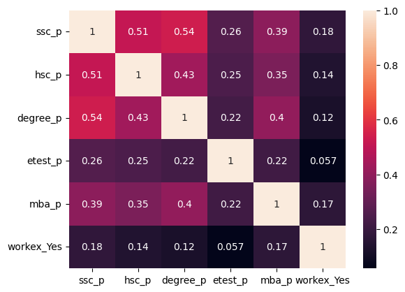

```python
x3 = dfdm[['ssc_p', 'hsc_p', 'degree_p', 'etest_p', 'mba_p', 'workex_Yes']]
y2 = dfdm['salary']
x3.corr()
sns.heatmap(x3.corr(),annot=True)
```

ssc_p và hsc_p có hệ số tương quan 0.51: Tương quan dương trung bình, tức là điểm trung học cơ sở (ssc_p) và điểm trung học phổ thông (hsc_p) có mối quan hệ dương.

ssc_p và workex_Yes có hệ số tương quan 0.18: Tương quan dương rất yếu, tức là điểm trung học cơ sở (ssc_p) gần như không liên quan đến việc có kinh nghiệm làm việc (workex_Yes).

etest_p và degree_p có hệ số tương quan 0.22: Mối tương quan dương yếu. ssc_p và degree_p có hệ số tương quan 0.54: Một mối quan hệ dương trung bình, nghĩa là điểm trung học cơ sở có xu hướng liên quan đến điểm đại học ở mức vừa phải.

etest_p và workex_Yes có hệ số tương quan 0.057: Gần như không có mối tương quan tuyến tính.

```python
print(df.columns)
```

```
Index(['sl_no', 'gender', 'ssc_p', 'ssc_b', 'hsc_p', 'hsc_b', 'hsc_s',
       'degree_p', 'degree_t', 'workex', 'etest_p', 'specialisation', 'mba_p',
       'status', 'salary'],
      dtype='object')
```

```python
print(dfdm[features].dtypes)
dfdm['workex_Yes'] = dfdm['workex_Yes'].astype(float)
```

```
ssc_p         float64
hsc_p         float64
degree_p      float64
etest_p       float64
mba_p         float64
workex_Yes       bool
dtype: object
```

```python
from statsmodels.stats.outliers_influence import variance_inflation_factor
from statsmodels.tools.tools import add_constant

def compute_vif(considered_features):

    X = dfdm[considered_features]
    X['intercept'] = 1

    vif = pd.DataFrame()
    vif["Variable"] = X.columns
    vif["VIF"] = [variance_inflation_factor(X.values, i) for i in range(X.shape[1])]
    vif = vif[vif['Variable']!='intercept']
    return vif


features = ['ssc_p', 'hsc_p', 'degree_p', 'etest_p', 'mba_p', 'workex_Yes']
compute_vif(features).sort_values('VIF', ascending=False)
```

|  | Variable | VIF |
| --- | --- | --- |
| 0 | ssc_p | 1.698360 |
| 2 | degree_p | 1.555590 |
| 1 | hsc_p | 1.472954 |
| 4 | mba_p | 1.308945 |
| 3 | etest_p | 1.109405 |
| 5 | workex_Yes | 1.046392 |

```python
X4 = dfdm[['ssc_p', 'hsc_p', 'degree_p', 'etest_p', 'mba_p', 'workex_Yes']]
y4 = dfdm['salary']

X4 = sm.add_constant(X4)

model = sm.OLS(y4, X4).fit()
print(model.summary())
```

```
                            OLS Regression Results
==============================================================================
Dep. Variable:                 salary   R-squared:                       0.406
Model:                            OLS   Adj. R-squared:                  0.389
Method:                 Least Squares   F-statistic:                     23.70
Date:                Mon, 16 Dec 2024   Prob (F-statistic):           2.78e-21
Time:                        15:55:31   Log-Likelihood:                -2817.8
No. Observations:                 215   AIC:                             5650.
Df Residuals:                     208   BIC:                             5673.
Df Model:                           6
Covariance Type:            nonrobust
==============================================================================
                 coef    std err          t      P>|t|      [0.025      0.975]
------------------------------------------------------------------------------
const      -3.227e+05   1.01e+05     -3.185      0.002   -5.22e+05   -1.23e+05
ssc_p       5232.2796    995.542      5.256      0.000    3269.634    7194.926
hsc_p       3228.3040    921.146      3.505      0.001    1412.325    5044.283
degree_p    3271.4068   1401.861      2.334      0.021     507.730    6035.084
etest_p      342.4541    656.206      0.522      0.602    -951.214    1636.122
mba_p      -4986.7234   1622.188     -3.074      0.002   -8184.761   -1788.686
workex_Yes   6.92e+04   1.78e+04      3.895      0.000    3.42e+04    1.04e+05
==============================================================================
Omnibus:                       92.968   Durbin-Watson:                   2.011
Prob(Omnibus):                  0.000   Jarque-Bera (JB):              512.478
Skew:                           1.594   Prob(JB):                    5.21e-112
Kurtosis:                       9.859   Cond. No.                     1.85e+03
==============================================================================

Notes:
[1] Standard Errors assume that the covariance matrix of the errors is correctly specified.
[2] The condition number is large, 1.85e+03. This might indicate that there are
strong multicollinearity or other numerical problems.
```

```python
from sklearn.model_selection import train_test_split
import statsmodels.api as sm
from sklearn.linear_model import LinearRegression

y4 = dfdm['salary']
X4 = dfdm[['ssc_p', 'hsc_p', 'degree_p', 'etest_p', 'mba_p', 'workex_Yes']]

testperc=0.3
X_train5, X_test5, y_train5, y_test5 = train_test_split(X4, y4, test_size = testperc, random_state = 0)
est = LinearRegression(fit_intercept=True)
est.fit(pd.DataFrame(X_train5),pd.DataFrame(y_train5))

print("The cofficient(s) b is(are)",est.coef_)
print("The intercept a is", est.intercept_)

X_train5 = sm.add_constant(X_train5) # This adds an intercept
model = sm.OLS(y_train5,X_train5)
results = model.fit()
results.summary()
```

```
The cofficient(s) b is(are) [[ 6250.7256616   3398.39066599  2757.7451946   -245.75181454
  -3862.23352857 84639.86576115]]
The intercept a is [-391663.18620259]
```

OLS Regression Results

| Dep. Variable: | salary | R-squared: | 0.424 |
| --- | --- | --- | --- |
| Model: | OLS | Adj. R-squared: | 0.400 |
| Method: | Least Squares | F-statistic: | 17.55 |
| Date: | Mon, 16 Dec 2024 | Prob (F-statistic): | 3.63e-15 |
| Time: | 15:55:31 | Log-Likelihood: | -1972.6 |
| No. Observations: | 150 | AIC: | 3959. |
| Df Residuals: | 143 | BIC: | 3980. |
| Df Model: | 6 |  |  |
| Covariance Type: | nonrobust |  |  |

|  | coef | std err | t | P>\|t\| | [0.025 | 0.975] |
| --- | --- | --- | --- | --- | --- | --- |
| const | -3.917e+05 | 1.26e+05 | -3.115 | 0.002 | -6.4e+05 | -1.43e+05 |
| ssc_p | 6250.7257 | 1309.310 | 4.774 | 0.000 | 3662.623 | 8838.828 |
| hsc_p | 3398.3907 | 1164.504 | 2.918 | 0.004 | 1096.525 | 5700.256 |
| degree_p | 2757.7452 | 1766.662 | 1.561 | 0.121 | -734.402 | 6249.893 |
| etest_p | -245.7518 | 819.940 | -0.300 | 0.765 | -1866.520 | 1375.017 |
| mba_p | -3862.2335 | 2033.786 | -1.899 | 0.060 | -7882.403 | 157.936 |
| workex_Yes | 8.464e+04 | 2.26e+04 | 3.753 | 0.000 | 4.01e+04 | 1.29e+05 |

| Omnibus: | 74.798 | Durbin-Watson: | 2.217 |
| --- | --- | --- | --- |
| Prob(Omnibus): | 0.000 | Jarque-Bera (JB): | 418.285 |
| Skew: | 1.716 | Prob(JB): | 1.48e-91 |
| Kurtosis: | 10.426 | Cond. No. | 1.81e+03 |

Notes:  
[1] Standard Errors assume that the covariance matrix of the errors is correctly specified.  
[2] The condition number is large, 1.81e+03. This might indicate that there are  
strong multicollinearity or other numerical problems.

```python
y4 = dfdm['salary']
X4 = dfdm[['ssc_p', 'hsc_p', 'degree_p', 'mba_p', 'workex_Yes']]

testperc=0.3
X_train5, X_test5, y_train5, y_test5 = train_test_split(X4, y4, test_size = testperc, random_state = 0)
est = LinearRegression(fit_intercept=True)
est.fit(pd.DataFrame(X_train5),pd.DataFrame(y_train5))

print("The cofficient(s) b is(are)",est.coef_)
print("The intercept a is", est.intercept_)

X_train5 = sm.add_constant(X_train5) # This adds an intercept
model = sm.OLS(y_train5,X_train5)
results = model.fit()
results.summary()
```

```
The cofficient(s) b is(are) [[ 6192.72672584  3386.53287549  2722.32468202 -3916.95181365
  84829.58149968]]
The intercept a is [-399138.28335064]
```

OLS Regression Results

| Dep. Variable: | salary | R-squared: | 0.424 |
| --- | --- | --- | --- |
| Model: | OLS | Adj. R-squared: | 0.404 |
| Method: | Least Squares | F-statistic: | 21.18 |
| Date: | Mon, 16 Dec 2024 | Prob (F-statistic): | 7.74e-16 |
| Time: | 15:55:31 | Log-Likelihood: | -1972.7 |
| No. Observations: | 150 | AIC: | 3957. |
| Df Residuals: | 144 | BIC: | 3975. |
| Df Model: | 5 |  |  |
| Covariance Type: | nonrobust |  |  |

|  | coef | std err | t | P>\|t\| | [0.025 | 0.975] |
| --- | --- | --- | --- | --- | --- | --- |
| const | -3.991e+05 | 1.23e+05 | -3.250 | 0.001 | -6.42e+05 | -1.56e+05 |
| ssc_p | 6192.7267 | 1290.832 | 4.797 | 0.000 | 3641.301 | 8744.153 |
| hsc_p | 3386.5329 | 1160.148 | 2.919 | 0.004 | 1093.414 | 5679.652 |
| degree_p | 2722.3247 | 1757.126 | 1.549 | 0.124 | -750.766 | 6195.415 |
| mba_p | -3916.9518 | 2019.164 | -1.940 | 0.054 | -7907.981 | 74.077 |
| workex_Yes | 8.483e+04 | 2.25e+04 | 3.775 | 0.000 | 4.04e+04 | 1.29e+05 |

| Omnibus: | 74.103 | Durbin-Watson: | 2.209 |
| --- | --- | --- | --- |
| Prob(Omnibus): | 0.000 | Jarque-Bera (JB): | 407.650 |
| Skew: | 1.703 | Prob(JB): | 3.02e-89 |
| Kurtosis: | 10.323 | Cond. No. | 1.55e+03 |

Notes:  
[1] Standard Errors assume that the covariance matrix of the errors is correctly specified.  
[2] The condition number is large, 1.55e+03. This might indicate that there are  
strong multicollinearity or other numerical problems.

```python
y4 = dfdm['salary']
X4 = dfdm[['ssc_p', 'hsc_p', 'mba_p', 'workex_Yes']]

testperc=0.3
X_train5, X_test5, y_train5, y_test5 = train_test_split(X4, y4, test_size = testperc, random_state = 0)
est = LinearRegression(fit_intercept=True)
est.fit(pd.DataFrame(X_train5),pd.DataFrame(y_train5))

print("The cofficient(s) b is(are)",est.coef_)
print("The intercept a is", est.intercept_)

X_train5 = sm.add_constant(X_train5) # This adds an intercept
model = sm.OLS(y_train5,X_train5)
results = model.fit()
results.summary()
```

```
The cofficient(s) b is(are) [[ 6834.94859722  3845.44638885 -3400.73960838 85477.31576103]]
The intercept a is [-325396.87106653]
```

OLS Regression Results

| Dep. Variable: | salary | R-squared: | 0.414 |
| --- | --- | --- | --- |
| Model: | OLS | Adj. R-squared: | 0.398 |
| Method: | Least Squares | F-statistic: | 25.63 |
| Date: | Mon, 16 Dec 2024 | Prob (F-statistic): | 4.52e-16 |
| Time: | 15:55:31 | Log-Likelihood: | -1973.9 |
| No. Observations: | 150 | AIC: | 3958. |
| Df Residuals: | 145 | BIC: | 3973. |
| Df Model: | 4 |  |  |
| Covariance Type: | nonrobust |  |  |

|  | coef | std err | t | P>\|t\| | [0.025 | 0.975] |
| --- | --- | --- | --- | --- | --- | --- |
| const | -3.254e+05 | 1.14e+05 | -2.860 | 0.005 | -5.5e+05 | -1.01e+05 |
| ssc_p | 6834.9486 | 1228.353 | 5.564 | 0.000 | 4407.159 | 9262.738 |
| hsc_p | 3845.4464 | 1127.101 | 3.412 | 0.001 | 1617.778 | 6073.115 |
| mba_p | -3400.7396 | 2001.077 | -1.699 | 0.091 | -7355.788 | 554.308 |
| workex_Yes | 8.548e+04 | 2.26e+04 | 3.786 | 0.000 | 4.09e+04 | 1.3e+05 |

| Omnibus: | 69.473 | Durbin-Watson: | 2.192 |
| --- | --- | --- | --- |
| Prob(Omnibus): | 0.000 | Jarque-Bera (JB): | 350.265 |
| Skew: | 1.608 | Prob(JB): | 8.73e-77 |
| Kurtosis: | 9.760 | Cond. No. | 1.24e+03 |

Notes:  
[1] Standard Errors assume that the covariance matrix of the errors is correctly specified.  
[2] The condition number is large, 1.24e+03. This might indicate that there are  
strong multicollinearity or other numerical problems.

```python
y4 = dfdm['salary']
X4 = dfdm[['ssc_p', 'hsc_p', 'workex_Yes']]

testperc=0.3
X_train5, X_test5, y_train5, y_test5 = train_test_split(X4, y4, test_size = testperc, random_state = 0)
est = LinearRegression(fit_intercept=True)
est.fit(pd.DataFrame(X_train5),pd.DataFrame(y_train5))

print("The cofficient(s) b is(are)",est.coef_)
print("The intercept a is", est.intercept_)

X_train5 = sm.add_constant(X_train5) # This adds an intercept
model = sm.OLS(y_train5,X_train5)
results = model.fit()
results.summary()
```

```
The cofficient(s) b is(are) [[ 6388.15433549  3306.51324453 81257.4612063 ]]
The intercept a is [-469159.56554598]
```

OLS Regression Results

| Dep. Variable: | salary | R-squared: | 0.403 |
| --- | --- | --- | --- |
| Model: | OLS | Adj. R-squared: | 0.390 |
| Method: | Least Squares | F-statistic: | 32.78 |
| Date: | Mon, 16 Dec 2024 | Prob (F-statistic): | 2.92e-16 |
| Time: | 15:55:31 | Log-Likelihood: | -1975.4 |
| No. Observations: | 150 | AIC: | 3959. |
| Df Residuals: | 146 | BIC: | 3971. |
| Df Model: | 3 |  |  |
| Covariance Type: | nonrobust |  |  |

|  | coef | std err | t | P>\|t\| | [0.025 | 0.975] |
| --- | --- | --- | --- | --- | --- | --- |
| const | -4.692e+05 | 7.66e+04 | -6.126 | 0.000 | -6.21e+05 | -3.18e+05 |
| ssc_p | 6388.1543 | 1207.622 | 5.290 | 0.000 | 4001.476 | 8774.833 |
| hsc_p | 3306.5132 | 1088.539 | 3.038 | 0.003 | 1155.183 | 5457.843 |
| workex_Yes | 8.126e+04 | 2.26e+04 | 3.598 | 0.000 | 3.66e+04 | 1.26e+05 |

| Omnibus: | 62.207 | Durbin-Watson: | 2.195 |
| --- | --- | --- | --- |
| Prob(Omnibus): | 0.000 | Jarque-Bera (JB): | 291.353 |
| Skew: | 1.434 | Prob(JB): | 5.41e-64 |
| Kurtosis: | 9.196 | Cond. No. | 692. |

Notes:  
[1] Standard Errors assume that the covariance matrix of the errors is correctly specified.

Biến ssc_p,hsc_p,workex_Yes là yếu tố duy nhất có ý nghĩa thống kê với mức tin cậy 95%.

```python
ylasso = dfdm['salary']
Xlasso = dfdm[['ssc_p', 'hsc_p', 'degree_p', 'mba_p', 'workex_Yes']]

testperc=0.3
X_train6, X_test6, y_train6, y_test6 = train_test_split(Xlasso, ylasso, test_size = testperc, random_state = 0)

# Prepare and fit the model
lasso_model = Lasso(alpha=0.01)
lasso_model.fit(X_train6, y_train6)
print("Lasso Coefficients: ", lasso_model.coef_)

# Predict the test set and evaluate using MSE
y_pred = lasso_model.predict(X_test6)
mse = mean_squared_error(y_test6, y_pred)
print("Mean Squared Error (test): ", mse)

y_pred5 = lasso_model.predict(X_train6)
mse2 = mean_squared_error(y_train6, y_pred5)
print("Mean Squared Error (train): ", mse2)
```

```
Lasso Coefficients:  [ 6192.72695197  3386.53277025  2722.324519   -3916.95085295
 84829.53450058]
Mean Squared Error (test):  12186419357.459648
Mean Squared Error (train):  15506224448.8667
```

```python
scaler = StandardScaler()
Xlasso_scaled = scaler.fit_transform(Xlasso)

X_train6_scaled, X_test6_scaled, y_train6, y_test6 = train_test_split(Xlasso_scaled, ylasso, test_size=0.3, random_state=0)

lasso_cv = LassoCV(alphas=[0.0001, 0.001, 0.01, 0.1, 1, 10, 50], cv=10, random_state=0)
lasso_cv.fit(X_train6_scaled, y_train6)

best_alpha = lasso_cv.alpha_
lasso_coefficients = lasso_cv.coef_
print(lasso_cv.alpha_)
print(lasso_cv.coef_)

#metrics
print(lasso_cv.score(X_test6, y_test6))
print(lasso_cv.mse_path_)
y_pred_test = lasso_cv.predict(X_test6_scaled)
y_pred_train = lasso_cv.predict(X_train6_scaled)

mse_test = mean_squared_error(y_test6, y_pred_test)
mse_train = mean_squared_error(y_train6, y_pred_train)
r2_test = r2_score(y_test6, y_pred_test)
r2_train = r2_score(y_train6, y_pred_train)

results = {
    "Best Alpha": best_alpha,
    "Coefficients": lasso_coefficients,
    "MSE Train": mse_train,
    "MSE Test": mse_test,
    "R2 Train": r2_train,
    "R2 Test": r2_test,
}

results
```

```
50.0
[ 66851.9283962   36771.10188627  19943.95914196 -22687.28042747
  40251.99167531]
-3016.8891329341786
[[5.41351934e+09 1.34071900e+10 9.68233075e+09 2.53570863e+10
  5.51572514e+09 4.59149160e+10 6.81532160e+09 2.80189900e+10
  1.80931915e+10 6.48931483e+09]
 [5.41810270e+09 1.33970701e+10 9.69315473e+09 2.53567651e+10
  5.52154959e+09 4.59175280e+10 6.81406862e+09 2.80202394e+10
  1.80816585e+10 6.49403155e+09]
 [5.41923330e+09 1.33947533e+10 9.69485028e+09 2.53567078e+10
  5.52289686e+09 4.59179465e+10 6.81391813e+09 2.80206398e+10
  1.80790399e+10 6.49506989e+09]
 [5.41935634e+09 1.33945184e+10 9.69494719e+09 2.53567007e+10
  5.52303382e+09 4.59179719e+10 6.81391508e+09 2.80206991e+10
  1.80788281e+10 6.49517297e+09]
 [5.41936837e+09 1.33944953e+10 9.69495956e+09 2.53566994e+10
  5.52304724e+09 4.59179752e+10 6.81391422e+09 2.80207055e+10
  1.80788049e+10 6.49518324e+09]
 [5.41936958e+09 1.33944929e+10 9.69496076e+09 2.53566993e+10
  5.52304859e+09 4.59179755e+10 6.81391414e+09 2.80207061e+10
  1.80788026e+10 6.49518427e+09]
 [5.41936970e+09 1.33944927e+10 9.69496088e+09 2.53566993e+10
  5.52304873e+09 4.59179755e+10 6.81391413e+09 2.80207062e+10
  1.80788024e+10 6.49518437e+09]]
```

```
{'Best Alpha': 50.0,
 'Coefficients': array([ 66851.9283962 ,  36771.10188627,  19943.95914196, -22687.28042747,
         40251.99167531]),
 'MSE Train': 15506239007.769615,
 'MSE Test': 12183042604.006943,
 'R2 Train': 0.4237812894566425,
 'R2 Test': 0.26865101801306757}
```

**RIDGE**

```python
from sklearn.model_selection import train_test_split
from sklearn.linear_model import Ridge, RidgeCV
from sklearn.metrics import mean_squared_error

yr = dfdm['salary']
Xr = dfdm[['ssc_p', 'hsc_p', 'degree_p', 'mba_p', 'workex_Yes']]

testperc=0.3
X_trainr, X_testr, y_trainr, y_testr = train_test_split(Xr, yr, test_size = testperc, random_state = 0)

# Prepare and fit the model
ridgeReg = Ridge(alpha=5)
ridgeReg.fit(X_trainr,y_trainr)
print("Ridge Coefficients: ", lasso_model.coef_)

# Predict the test set and evaluate using MSE
y_predr = ridgeReg.predict(X_testr)
mse = mean_squared_error(y_testr, y_predr)
print("Mean Squared Error (test): ", mse)

y_predr3 = ridgeReg.predict(X_trainr)
mse2 = mean_squared_error(y_trainr, y_predr3)
print("Mean Squared Error (train): ", mse2)
```

```
Ridge Coefficients:  [ 6192.72695197  3386.53277025  2722.324519   -3916.95085295
 84829.53450058]
Mean Squared Error (test):  11967804942.717812
Mean Squared Error (train):  15534262687.20679
```

```python
from sklearn.linear_model import RidgeCV
ridge_cv = RidgeCV(alphas = [0.1,1,2,5,10],cv=5).fit(X_trainr, y_trainr.to_numpy().ravel())

#best alpha
print(ridge_cv.alpha_)
print(ridge_cv.coef_)

#metrics
print(ridge_cv.score(X_testr, y_testr))
```

```
1.0
[ 6208.6362386   3385.4455256   2725.79283885 -3891.25958015
 82258.32641856]
0.27169683753711393
```